# Lab 3 - Clustering Analysis

# 7. Modeling and Evaluation 4: Summarize the Ramifications

```python
display(Markdown(model_reg_stats.sort_values(by = ["MAE"]).to_markdown()))
```

|  | model_name | RMSE | MAPE | MAE | time_refit |
| --- | --- | --- | --- | --- | --- |
| 0 | Random Forest-Clustered | 9529.95 | 91.1892 | 4192.67 | 13.5008 |
| 0 | Random Forest | 9532.32 | 91.2587 | 4196.27 | 14.9814 |
| 0 | Linear Reg | 9919 | 99.9211 | 4416.63 | 0.018466 |
| 0 | Linear Reg-Clustered | 9916.37 | 100.724 | 4431.57 | 0.0181818 |
| 0 | Elastic Net-Clustered | 16196.9 | 207.185 | 7227.27 | 0.00704503 |
| 0 | Elastic Net Reg | 16299.2 | 217.555 | 7412.7 | 0.0051589 |

Based on the results above, we see that regression model types dominate the MAE results, and in each type of the model, we see little influence from the clustering. MAE scores are not always better for non clustering models and processing time is not always reduced for clustering models. There is no evidence that our assumption of the players can be clustered into different groups from the attacking features. However, since the clustering technique reduces the number of features we fit to the models. If the dataset is large, it can potentially reduce the processing time. In addition, we can potentially further reduce the processing time by clustering the other skillsets, e.g. mental, defending, movement and power features as we did for the attacking features.

Below is a summary of our clustering models with MAE score.

```python
df_clustersummary.reset_index(drop = True)
```

|  | model_name | BestCluster | Param | MAE |
| --- | --- | --- | --- | --- |
| 0 | KMeans | 3 | 3 clusters | 4600.36 |
| 1 | AgglomerativeClustering | 3 | link=complete, 3 clusters | 4586.09 |
| 2 | DBScan | 3 | minpoint=6, eps=.125 | 4568.05 |

For KMeans algorithm, there is an elbow at $k=3$. Then $k=3$ is the good choice based on elbow plot. Any lower value would be dramatic while any higher value would not help much. Another method that we used is silhouette score. This is the mean silhouette coefficient over the instances. In addition, with the silhouette diagram, we get more informative visualization. By the elbow plot, the silhouette diagram and MAE score, we arrive to choose $k=3$ for KMeans algorithm.

For DBSCAN algorithm, by using MAE score, the best instance's neigborhood is 0.125 and a core instance has at least 6 instances in its 0.125-neighborhood (including itself). The core instances are located in dense regions. This algorithm considers clusters as continuous regions of high density and the best number of clusters is 3.

For Agglomerative clustering algorithm, still using MAE score to evaluate models, the best number of clusters is 3 with complete linkage (the maximum distances between all observations of the two sets).

Since we were unable to get a MAE score on other clustering algoritms we did not include them in the table above, but the analysis of them are documented in the section above the algorithms in the notebook.

⏫ Table of Contents

# 8. Deployment

Soccer clubs will be interested in our analyses. The Random Forest model with clustered features provide estimate of soccer players salary predictions. Clubs can offer salary when acquiring players base on the predictions. Also, the predictions can be a good reference when negotiating salary.

When a club is considering to trade players, we can deploy our models. For trading players, we can select players who the estimate salary are in the range of the budget. When there is a player the club wants to acquire, depending on how much desire the club wants to player, club can take the estimate salary as a reference. If the club thinks the player will fit well, it may offer salary that is higher than the estimate salary from our model. Also, when acquiring younger and newer players, the estimate salary can be a good reference because our model is driven by players' skills. We should collect the players' contract information so we can find out which players can be traded. Also, we can scrub players related news data so we can better understand players desires or preference.

The model need to be updated before trading windows or when club has a plan to trade a player. We can also potentially use the same strategy for other sport clubs, like football, volleyball, basketball, etc.

⏫ Table of Contents

# 9. Exceptional Work

```python
#Create the PCA on the original attacking attributes and clusters on the origianl attributes.

# For k=4
cluster = KMeans(n_clusters=4, random_state=10)
df1['cluster'] = cluster.fit_predict(X_players_attack_scaled)

# Take customer names and clusters from the pivot dataframe
df1_short = pd.DataFrame(df1['cluster']).reset_index()

# Initialize and fit a PCA with 2 components
pca = PCA(n_components=2)
# Transform the values matrix
X = pca.fit_transform(X_players_attack_scaled)

# Concatenate the data frames
df1_short_2 = pd.DataFrame(X, columns=['x', 'y'])
df_pca = pd.concat([df1_short, df1_short_2], axis=1)
```

Visualize PCA1,2 vs four clusters

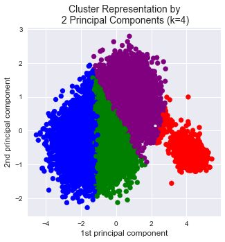

```python
#PCA

# For k=4
cluster = KMeans(n_clusters=4, random_state=10)
df1['cluster'] = cluster.fit_predict(X_players_attack_scaled)

# Take customer names and clusters from the pivot dataframe
df1_short = pd.DataFrame(df1['cluster']).reset_index()

# Initialize and fit a PCA with 2 components
pca = PCA(n_components=2)
# Transform the values matrix
X = pca.fit_transform(X_players_attack_scaled)

# Concatenate the data frames
df1_short_2 = pd.DataFrame(X, columns=['x', 'y'])
df_pca = pd.concat([df1_short, df1_short_2], axis=1)

# Create a scatterplot of the reduced data when k=5 as shown through the elbow plot
plt.rcParams["figure.figsize"] = (5,5)
colors = {0:'blue', 1:'red', 2:'green', 3:'purple', 4:'yellow'}
plt.scatter(x=df_pca['x'], y=df_pca['y'], c=df1['cluster'].apply(lambda x: colors[x]))
plt.xticks(size=10)
plt.xlabel('1st principal component', size=12)
plt.yticks(size=10)
plt.ylabel('2nd principal component', size=12)
plt.title('Cluster Representation by\n 2 Principal Components (k=4)', size=14);
```

Visualize PCA1,2 vs two clusters

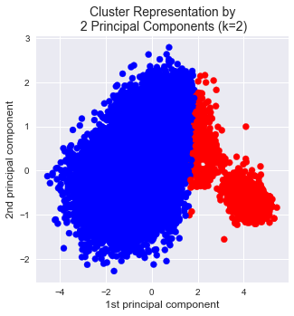

```python
#Visualize PCA1,2 vs four cluster

# For k=2
cluster = KMeans(n_clusters=2, random_state=10)
df1['cluster'] = cluster.fit_predict(X_players_attack_scaled)

# Take customer names and clusters from the pivot dataframe
df1_short = pd.DataFrame(df1['cluster']).reset_index()

# Initialize and fit a PCA with 2 components
pca = PCA(n_components=2)
# Transform the values matrix
X = pca.fit_transform(X_players_attack_scaled)

# Concatenate the data frames
df1_short_2 = pd.DataFrame(X, columns=['x', 'y'])
df_pca = pd.concat([df1_short, df1_short_2], axis=1)

# Create a scatterplot of the reduced data when k=5 as shown through the elbow plot
plt.rcParams["figure.figsize"] = (5,5)
colors = {0:'blue', 1:'red', 2:'green', 3:'purple', 4:'yellow'}
plt.scatter(x=df_pca['x'], y=df_pca['y'], c=df1['cluster'].apply(lambda x: colors[x]))
plt.xticks(size=10)
plt.xlabel('1st principal component', size=12)
plt.yticks(size=10)
plt.ylabel('2nd principal component', size=12)
plt.title('Cluster Representation by\n 2 Principal Components (k=2)', size=14);
```

Visualize PCA1,2 vs three clusters

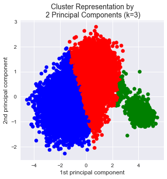

```python
#PCA

# For k=3
cluster = KMeans(n_clusters=3, random_state=10)
df1['cluster'] = cluster.fit_predict(X_players_attack_scaled)

# Take customer names and clusters from the pivot dataframe
df1_short = pd.DataFrame(df1['cluster']).reset_index()

# Initialize and fit a PCA with 2 components
pca = PCA(n_components=2)
# Transform the values matrix
X = pca.fit_transform(X_players_attack_scaled)

# Concatenate the data frames
df1_short_2 = pd.DataFrame(X, columns=['x', 'y'])
df_pca = pd.concat([df1_short, df1_short_2], axis=1)

# Create a scatterplot of the reduced data when k=5 as shown through the elbow plot
plt.rcParams["figure.figsize"] = (5,5)
colors = {0:'blue', 1:'red', 2:'green', 3:'purple', 4:'yellow'}
plt.scatter(x=df_pca['x'], y=df_pca['y'], c=df1['cluster'].apply(lambda x: colors[x]))
plt.xticks(size=10)
plt.xlabel('1st principal component', size=12)
plt.yticks(size=10)
plt.ylabel('2nd principal component', size=12)
plt.title('Cluster Representation by\n 2 Principal Components (k=3)', size=14);
```

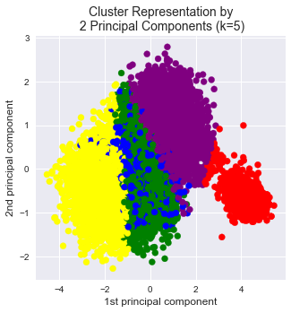

```python
#PCA

# For k=5
cluster = KMeans(n_clusters=5, random_state=10)
df1['cluster'] = cluster.fit_predict(X_players_attack_scaled)

# Take customer names and clusters from the pivot dataframe
df1_short = pd.DataFrame(df1['cluster']).reset_index()

# Initialize and fit a PCA with 2 components
pca = PCA(n_components=2)
# Transform the values matrix
X = pca.fit_transform(X_players_attack_scaled)

# Concatenate the data frames
df1_short_2 = pd.DataFrame(X, columns=['x', 'y'])
df_pca = pd.concat([df1_short, df1_short_2], axis=1)

# Create a scatterplot of the reduced data when k=5 as shown through the elbow plot
plt.rcParams["figure.figsize"] = (5,5)
colors = {0:'blue', 1:'red', 2:'green', 3:'purple', 4:'yellow'}
plt.scatter(x=df_pca['x'], y=df_pca['y'], c=df1['cluster'].apply(lambda x: colors[x]))
plt.xticks(size=10)
plt.xlabel('1st principal component', size=12)
plt.yticks(size=10)
plt.ylabel('2nd principal component', size=12)
plt.title('Cluster Representation by\n 2 Principal Components (k=5)', size=14);
```

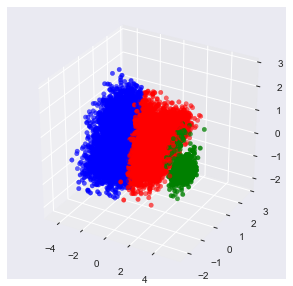

```python
# Plot in 3D with 3 components
# For k=3
cluster = KMeans(n_clusters=3, random_state=10)
df1['cluster'] = cluster.fit_predict(X_players_attack_scaled)

# Take customer names and clusters from the pivot dataframe
df1_short = pd.DataFrame(df1['cluster']).reset_index()

# Initialize and fit a PCA with 3 components
pca = PCA(n_components=3)
# Transform the values matrix
X = pca.fit_transform(X_players_attack_scaled)

# Concatenate the data frames
df1_short_2 = pd.DataFrame(X, columns=['x', 'y', 'z'])
df_pca = pd.concat([df1_short, df1_short_2], axis=1)

# plot in 3D
from mpl_toolkits.mplot3d import axes3d, Axes3D
fig = plt.figure()
ax = fig.add_subplot(111, projection='3d')
ax.scatter(
    xs=df_pca['x'].values,
    ys=df_pca['y'].values,
    zs=df_pca['z'].values,
    c=df_pca['cluster'].apply(lambda x: colors[x])
)
plt.show()
```